# Understanding Confounding Limits

Chris McKennan

June 17, 2016

This file uses simulations to try and understand when we do and do not need training data. The confounding comes in the model through the term $\left( LD \right)\left(D^{-1}\Omega\right) X + \left( LD \right) \Xi$, where $\Xi \sim \left( 0,I_K,I_n \right)$ and $\Lambda = D^2$. What we know is if $LD$ is small, then the coefficient of variation $\frac{\mu}{\sigma/\sqrt{n}}$ will be small and we will not be able to recover the large correlation in $D^{-1}\Omega$. As $p \to \infty$, we will be able to recover it. The smaller $p$ is, however, the worse we do.

## Install Packages and Functions

```r
#library('minfi')
#library('RefFreeEWAS')
library('nlme')
library('knitr')
library('printr')
library('gtools')
library('leapp')
#install.packages("../RPackages/cate", type="source", repos=NULL)
library('esaBcv')
library('MASS')
library('ruv')
library('corpcor')
library('cate')
library('qvalue')
library('Rmosek')
source("chunk-options.R")
source("../R/OptimizeLogLike.R")
source("../R/OptimizeLogLike_Ksigma.R")
source("../R/SimSparseData.R")
source("../R/EstimateBeta.R")
source("../R/CrudeEstDim.R")
source("../R/AnalyzeSimResults.R")
source("../R/PartialEM.R")
```

## Estimate $\Omega$ and $\Lambda$ from Michelle’s Amish/Hutterite data

```r
path.cov <- "/Users/Chris/Desktop/Uchicago/Nicolae/DNAMethylation/MichellesData/AmishHutterite/HAmeth_covar_60null_123015.txt"
Cov.orig <- data.frame( read.table(path.cov, sep="\t", dec=".", header=T, check.names=F) )
ind.remove <- which(is.na(Cov.orig$Other))
Cov <- Cov.orig[-ind.remove,]
n.michelle <- nrow(Cov)

ind.cell <- c(1,3,4)
Age.cutoff <- 11.5   #Pre and post pubescent

K <- length(ind.cell)
X.all <- t(model.matrix(~sex + group + as.numeric(age > Age.cutoff), data=Cov))   #A d x n design matrix
d <- nrow(X.all)
C.all <- t(as.matrix( Cov[,31:ncol(Cov)] ))/100   #number of cell types x n matrix

beta.X.all <- solve( X.all %*% t(X.all) ) %*% X.all
H.all <- t(X.all) %*% beta.X.all
Omega.OLS <- C.all %*% t(beta.X.all)     #A K x d matrix
var.OLS <- diag(C.all %*% (diag(n.michelle)-H.all) %*% t(C.all))/(n.michelle-d)
var.stand <- var.OLS/Omega.OLS[,1]/(1-Omega.OLS[,1])

C.0 <- C.all[ind.cell,]      #Tcells, Eos, Neutrophils. This contains all individuals and is a K x d matrix
Omega.start <- Omega.OLS[ind.cell,]    #A K x d matrix
sigma.cell.start <- median(sqrt(var.stand[ind.cell]))

QL.Cell <- Compute.Omega.QL(X.all, C.0, Omega.start, 1e-8)
Omega.QL <- QL.Cell$Omega     #A K x d matrix
var.cell <- QL.Cell$v
Var.Omega <- solve(QL.Cell$FI)
```

## Generate and analyze synthetic data with CATE

For all proceeding simulations, I will assume only a single confounder (Neutrophils) with 70% sparsity, $n=200$ and $\sigma^2 = 0.15$. I will characterize the simulation using $LD$ and $D^{-1}\Omega$. In the below simulation, $\sigma_{LD} = 0.042$, $D^{-1}\Omega = -1.80$ and $\frac{\sigma}{\sqrt{n}} = 0.027$. Note that $\sigma_{LD}$ is on the order of $\frac{\sigma}{\sqrt{n}}$.

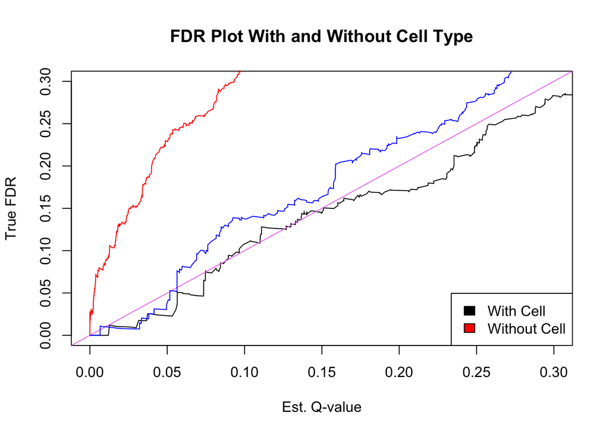

```r
p <- floor(327273/10)    #Number of usuable sites in a typical experiment
n.sim <- 200   #Number of individuals
r.sim <- 4     #Number of additional confounders
K.sim <- 3     #Number of cell types
d.sim <- 1     #Number of interesting covariates (either 0 or 1)
pi0.B.sim <- rep(0.95, d.sim)    #Sparsity in B
pi0.L.sim <- c(1, 1, 0.7)    #Sparsity in L
LB.ind <- 1     #Are L and B independent? If no, the confounder Eos will have nonzero effects on the same sites as B[nonzero,1]
mu.sigma.sim <- 0.15
v.sigma.sim <- 0.03^2
beta.sigma <- mu.sigma.sim/v.sigma.sim
alpha.sigma <- beta.sigma * mu.sigma.sim     #Sigma ~ Gamma(alpha.sigma, beta.sigma)
sigma.B.sim <- rep(mu.sigma.sim, d.sim)

Omega.sim <- Omega.QL
Omega.sim[3,3] <- Omega.QL[3,3] / 1
Omega.sim[1,3] <- 0.04
Omega.sim[2,3] <- 0.02
Omega.sim <- Omega.sim[,-c(2,4)]
alpha.cell.sim <- (1/var.cell - 1)
sigma.L.sim <- c(1, 1, 1) / Omega.QL[1:3,1] * sqrt(0.15)

sigma.r.sim <- c(0.15, 0.15, 0.15, 0.15)

##Simulate Data##
SimData <- Sim.Data(n.sim, r.sim, p, pi0.B.sim, pi0.L.sim, LB.ind, sigma.B.sim, sigma.L.sim, sigma.r.sim, Omega.sim, alpha.cell.sim, alpha.sigma, beta.sigma)
M.sim <- SimData$M.sim
X.sim <- SimData$X.sim
L.sim <- SimData$L.sim
B.sim <- SimData$B.sim
Sigma.sim <- SimData$Sigma.sim
Gamma.sim <- SimData$Gamma.sim
C.sim <- SimData$C.sim    #n x K.all matrix
data.sim <- data.frame(cbind(X.sim, C.sim))
colnames(data.sim) <- c("Intercept", "Cov1", "Tcells", "Eos", "Neutro")

##Analyze data with and without cell type data##
analyzed.data <- AnalyzeData2(M.sim, data.sim, r.sim, r.sim+1, B.sim, L.sim)

##Correct estimate for alpha##

L <- analyzed.data$cate.nocell$Gamma; Sigma <- analyzed.data$cate.nocell$Sigma
alpha <- solve(t(L) %*% (L / Sigma) - p/n.sim * diag(r.sim+1)) %*% t(L / Sigma) %*% M.sim %*% X.sim %*% solve(t(X.sim) %*% X.sim)
blup.W <- alpha %*% t(X.sim) + t(analyzed.data$cate.nocell$Z) %*% (diag(n.sim) - X.sim %*% solve(t(X.sim) %*% X.sim) %*% t(X.sim))
tmp.mat <- cbind(X.sim, t(blup.W))
dof <- n.sim - ncol(tmp.mat)
beta.sim <- M.sim %*% tmp.mat %*% solve(t(tmp.mat) %*% tmp.mat)
cov.sim <- solve(t(tmp.mat) %*% tmp.mat)
p.values.sim <- 2 - 2*pt( abs(beta.sim[,2]) / sqrt(Sigma) / sqrt(cov.sim[2,2]), df=dof )
q.values.sim <- qvalue(p.values.sim)
fsr.sim <- false.sign.results(B.sim[,1], beta.sim[,2], q.values.sim$qvalue)
lines(sort(q.values.sim$qvalue), fsr.sim$fdr, col="blue")
```

The above simulations indicate that under this scenario, we do poorly. For $p$ very large (and $r$ small), this appears to happen when $\frac{1}{p}\Gamma^T\Sigma^{-1}\Gamma = O\left( \frac{1}{n} \right)$ and the correlation $\frac{1}{p}\Gamma^T \Sigma^{-1}YX\left( X^TX \right)^{-1}$ is somewhat large. Note that as $n$ gets larger, the correlation we would need for this method to fail also becomes larger (for fixed $r$). This is because:
$$\hat{\Sigma}^{-1/2}\hat{\Gamma} = \hat{\Sigma}^{-1/2}\Gamma + R, \text{ where } \frac{1}{p}R^T R \approx \frac{1}{n}I_r \text{ for $p$ large}.$$
$$\Rightarrow \frac{1}{p}\hat{\Gamma}^T\hat{\Sigma}^{-1}\hat{\Gamma} = \frac{1}{p}\Gamma^T\hat{\Sigma}^{-1}\Gamma + \frac{1}{p}R^T R + \underbrace{\frac{1}{p}R^T \hat{\Sigma}^{-1/2}\Gamma + \frac{1}{p}\Gamma^T \hat{\Sigma}^{-1/2}R}_{\approx 0} \approx \frac{1}{p}\Gamma^T\hat{\Sigma}^{-1}\Gamma + \frac{1}{n}I_r \approx \frac{1}{p}\Gamma^T\Sigma^{-1}\Gamma + \frac{1}{n}I_r$$
If I then let $\hat{\alpha} = \left( \hat{\Gamma}^T\hat{\Sigma}^{-1}\hat{\Gamma} - \frac{p}{n}I_r \right)^{-1} \hat{\Gamma}^T \hat{\Sigma}^{-1}YX\left( X^TX \right)^{-1}$, I get the blue line and seem to correct the red line.